# 20_tangent_get_angle

## 20_tangent_get_angle

#### Question

1. A right triangle has an angle of $\theta$ radians. The adjacent leg has a length of 34 meters, and the opposite leg has a length of 27 meters. What is the angle measure $\theta$ in radians?

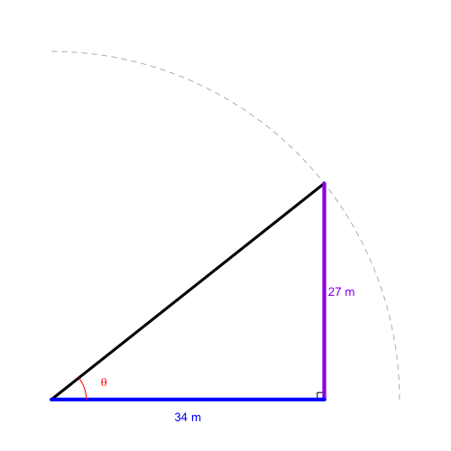

   Please round your answer to the nearest hundredth of a radian.

#### Question

2. A right triangle has an angle of $\theta$ radians. The adjacent leg has a length of 54 meters, and the opposite leg has a length of 74 meters. What is the angle measure $\theta$ in radians?

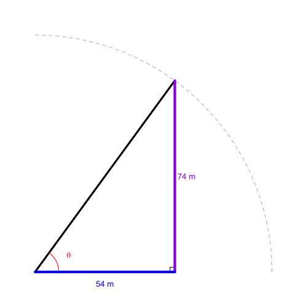

   Please round your answer to the nearest hundredth of a radian.

#### Question

3. A right triangle has an angle of $\theta$ radians. The adjacent leg has a length of 73 meters, and the opposite leg has a length of 52 meters. What is the angle measure $\theta$ in radians?

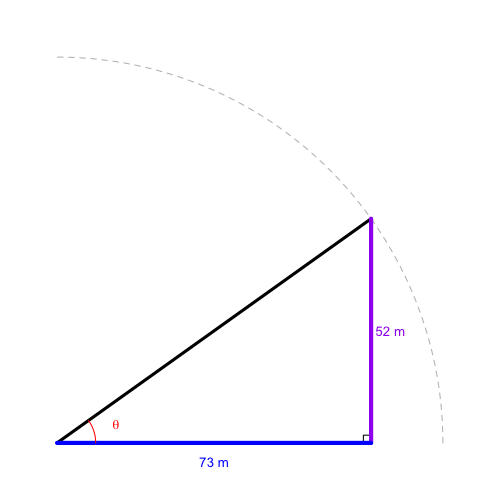

   Please round your answer to the nearest hundredth of a radian.

#### Question

4. A right triangle has an angle of $\theta$ radians. The adjacent leg has a length of 22 meters, and the opposite leg has a length of 66 meters. What is the angle measure $\theta$ in radians?

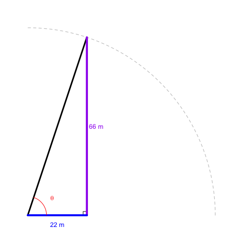

   Please round your answer to the nearest hundredth of a radian.

#### Question

5. A right triangle has an angle of $\theta$ radians. The adjacent leg has a length of 22 meters, and the opposite leg has a length of 16 meters. What is the angle measure $\theta$ in radians?

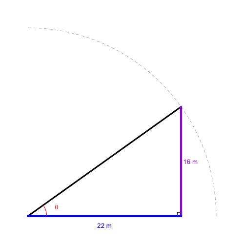

   Please round your answer to the nearest hundredth of a radian.

#### Question

6. A right triangle has an angle of $\theta$ radians. The adjacent leg has a length of 23 meters, and the opposite leg has a length of 38 meters. What is the angle measure $\theta$ in radians?

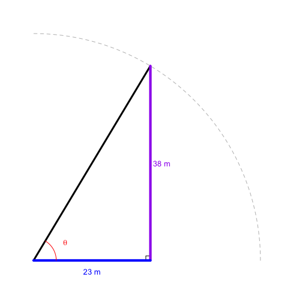

   Please round your answer to the nearest hundredth of a radian.

#### Question

7. A right triangle has an angle of $\theta$ radians. The adjacent leg has a length of 25 meters, and the opposite leg has a length of 49 meters. What is the angle measure $\theta$ in radians?

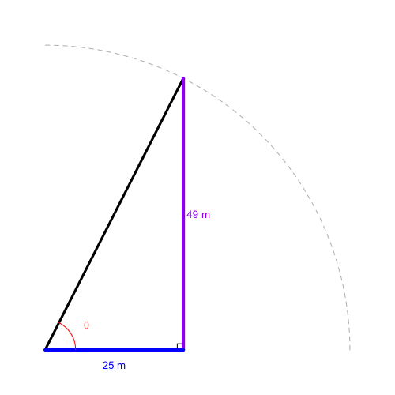

   Please round your answer to the nearest hundredth of a radian.

#### Question

8. A right triangle has an angle of $\theta$ radians. The adjacent leg has a length of 48 meters, and the opposite leg has a length of 86 meters. What is the angle measure $\theta$ in radians?

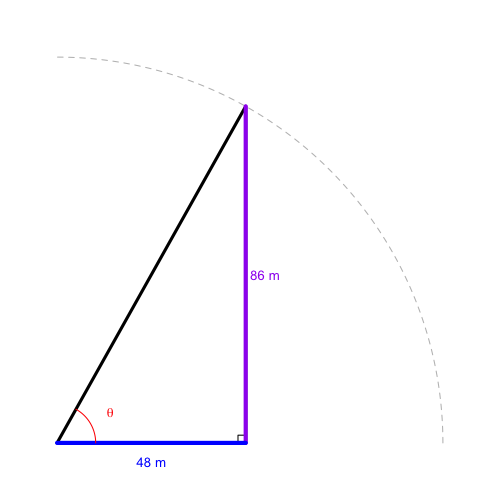

   Please round your answer to the nearest hundredth of a radian.